# First Generation Alumni Information

## Overall First Generation Alumni Visualizations

A large portion of the First Generation Alumni are under 30 years old, with some exceptions as shown below.

| Age Range | Count |
| --- | --- |
| 20 < 30 year olds | 1588 |
| 30 < 40 year olds | 88 |
| 40 < 50 year olds | 4 |
| 50 < 60 year olds | 2 |

Quartiles of Age Ranges, ie: 25% of First Generation Alumni are Under 24 years old.

|  | Age |
| --- | --- |
| 25% | 24 |
| 50% | 25 |
| 75% | 26 |
| 90% | 28 |
| 99% | 36 |

The median age of First Generation Alumni is 25 years old. Anyone over the age of 30 is considered an outlier.

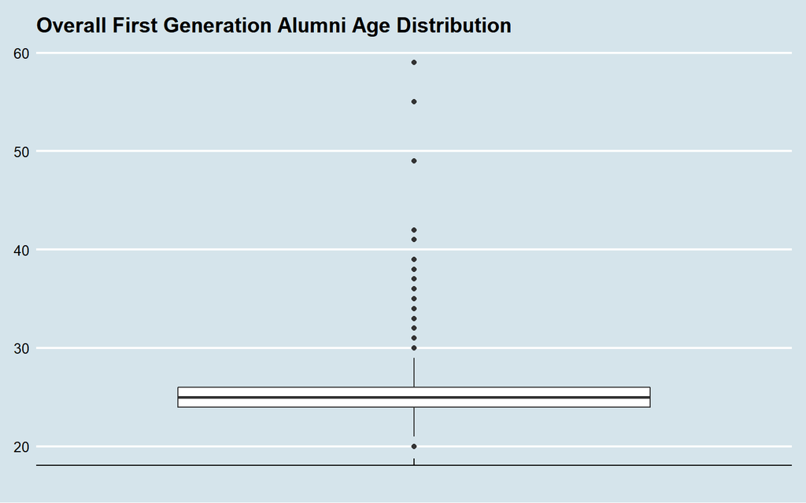

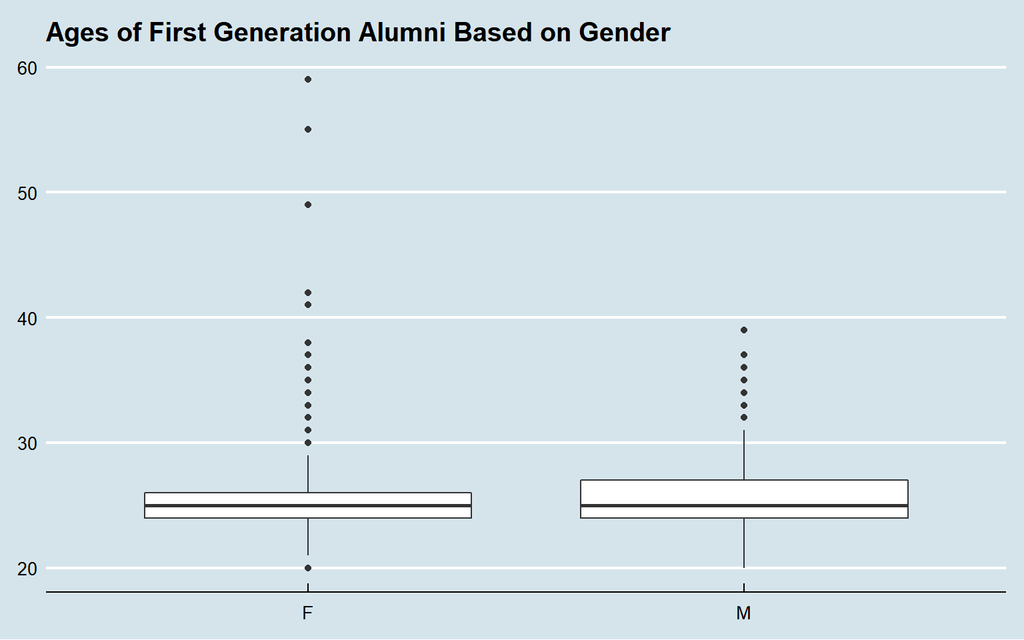

Visualizing First Generation Alumni based on their GPA per conferment year shows a slight upward trend since 2013.

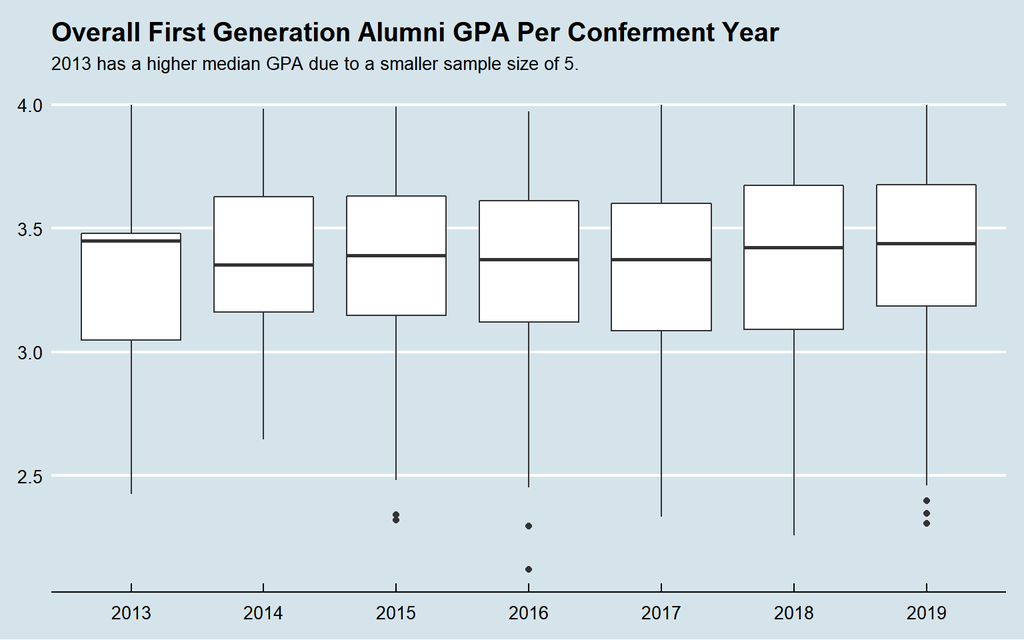

By describing the amount of individuals who were first generation alumni per year we can see that there has been an upward trend of more people. The exception being 2018, but following a huge increase in 2019 the trend seemingly will persist.

| Year | Count |
| --- | --- |
| 2013 | 5 |
| 2014 | 55 |
| 2015 | 300 |
| 2016 | 304 |
| 2017 | 336 |
| 2018 | 324 |
| 2019 | 358 |

The chart above can be broken down into this bar chart here for easy viewing.

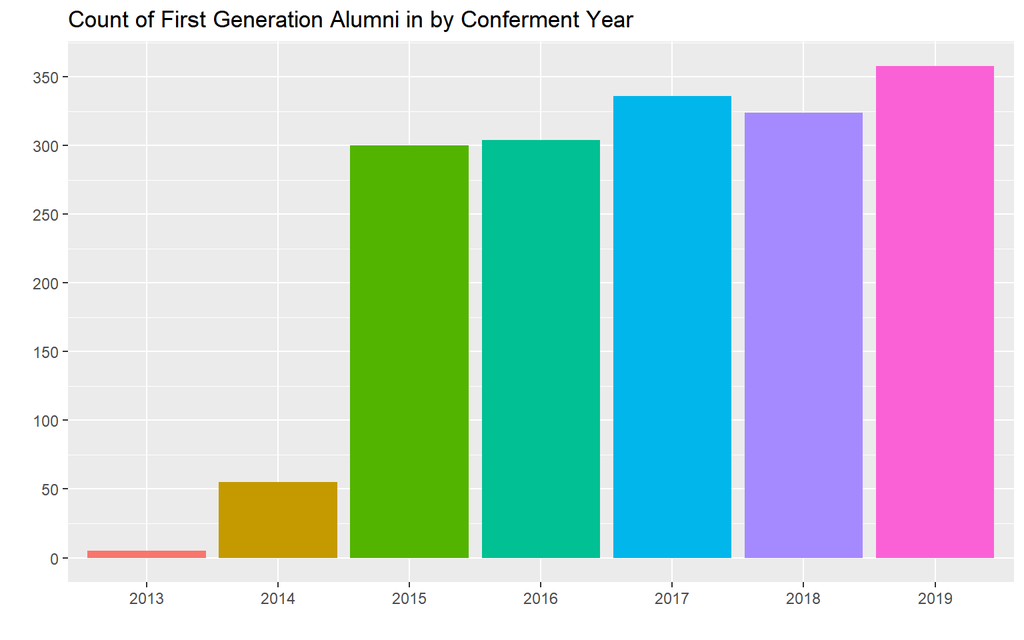

The overall distribution of Ethnicity from these first generation alumni is shown below in a table.

| Ethnicity | Count |
| --- | --- |
| Amer Ind/AK Ntv | 8 |
| Asian | 179 |
| Black/Afr Amer | 31 |
| Hispanic/Latino | 503 |
| Nonresident alien | 69 |
| Ntv HI/Other PI | 10 |
| Two or more races | 103 |
| Unknown | 53 |
| White | 726 |

This graph neatly visualizes the above table.

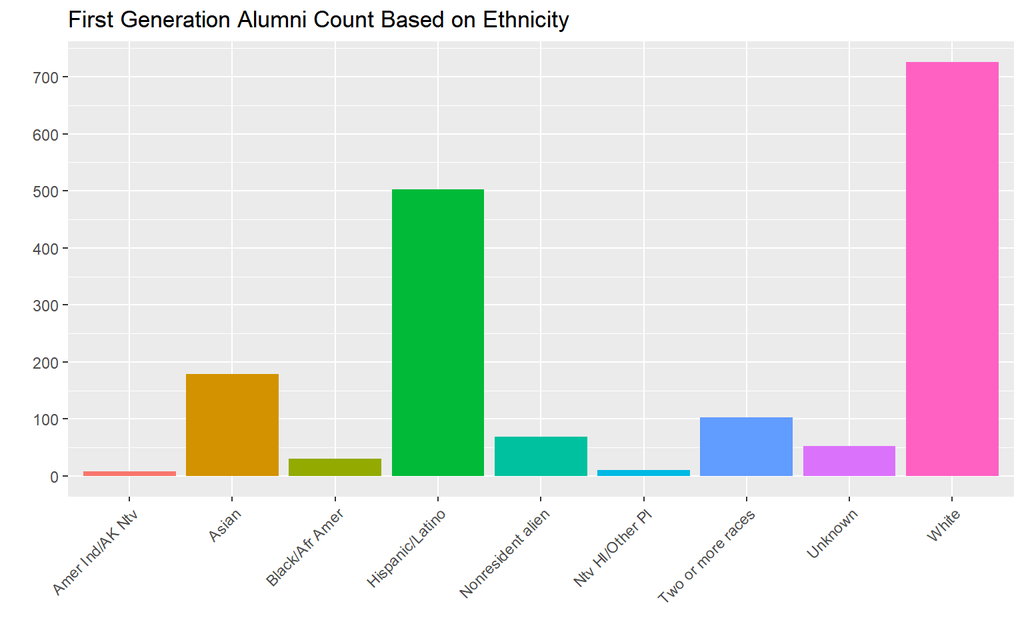

By breaking the ethnicities into age ranges we are able to see if there is a certain subset of ethnicity that may differ from the overall distribtion of age.

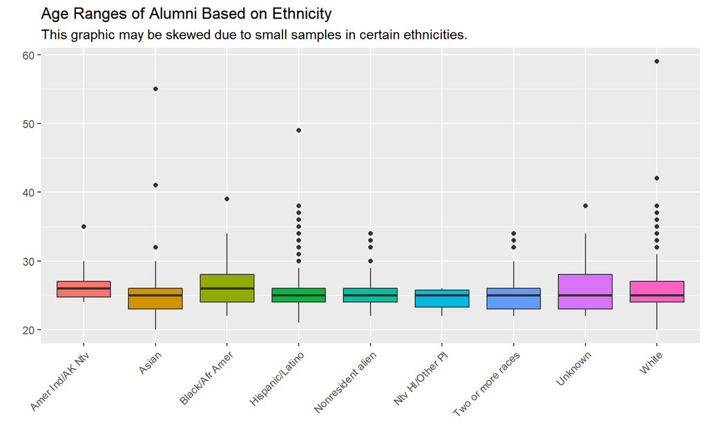

## Degree Visualization and Analysis

The most popular degrees are listed below. These are degrees that have over 100 first generation alumni graduating from the program.

[output not shown]

Accounting Degrees are one of the most popular degrees that were being acquired. It seems to be one of the most stable degrees in terms of number of students and will most likely remain that way.

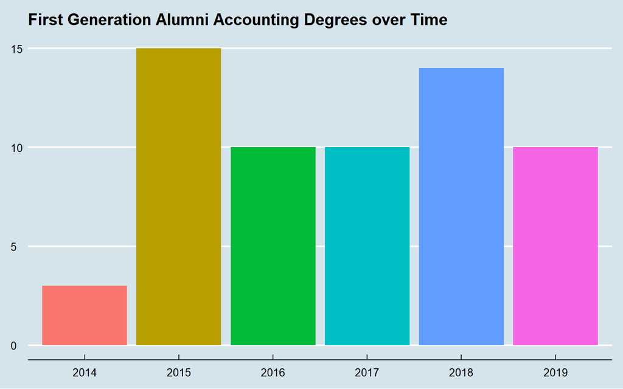

Business Administration degrees are the most popular degree for first generation alumni. This may be due to the fact that there are many emphases to choose from. Following the trend below this will remain one of the most popular degrees.

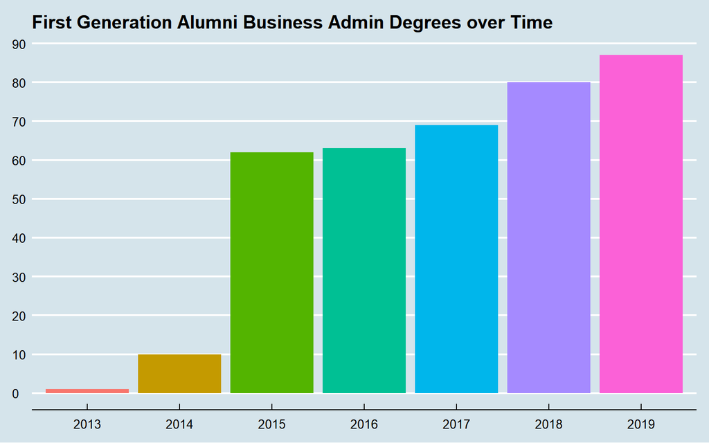

Communication Studies is another popular field of study, it peaked in 2016 and it is unsure if it will go back to 25+ concurrent graduating students.

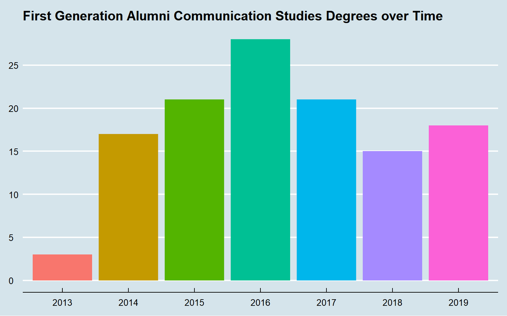

Health Sciences has shot up in popularity and rivalled 2015 levels last year, but if it follows previous trends the popularity of said degree may be cyclical or tied to specific events.

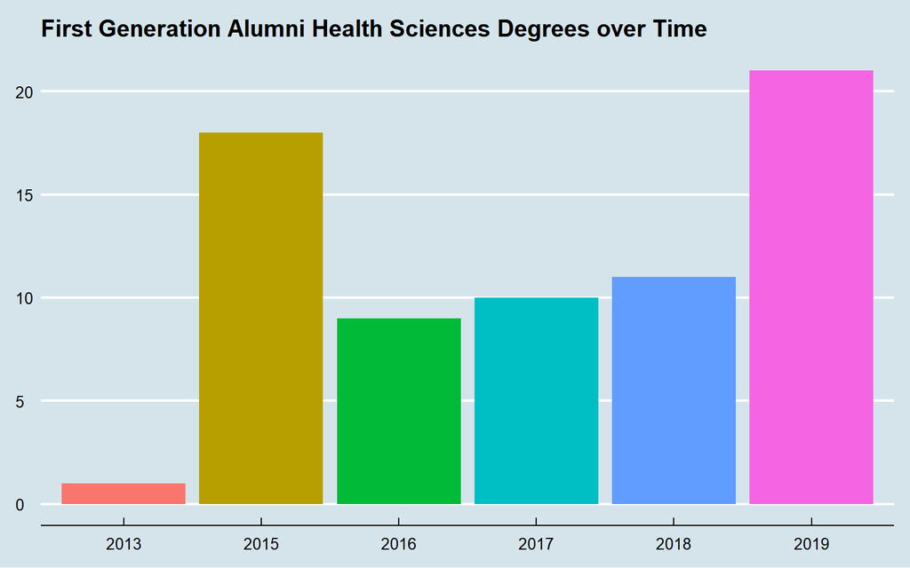

Educational Studies had a large increase in 2019 following a seemingly stable level for the past 4 years. It is unlikely that it will rise higher than this year, but it could stabilize at a slightly higher level than previously.

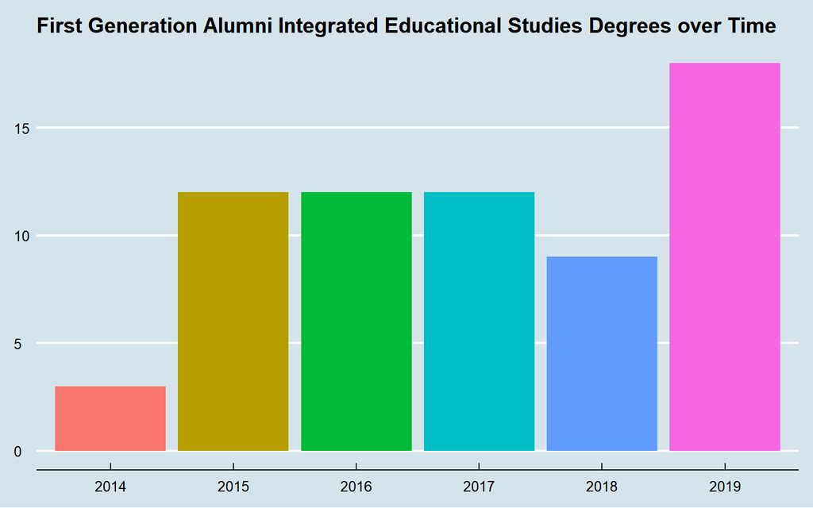

Political Science majors have increased significantly since 2016. Following a continuation of this trend this degree may remain at a higher interest level in the future.

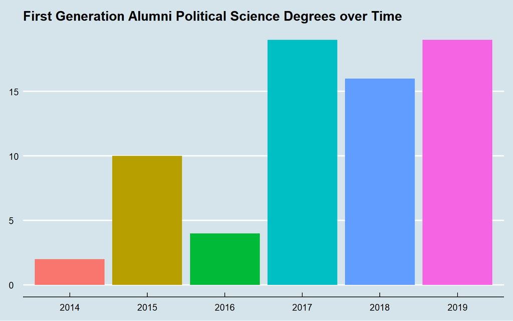

Psychology Degrees are trending up in 2019 after a couple years of decreasing numbers, but still not at back at it’s peak from 2015.

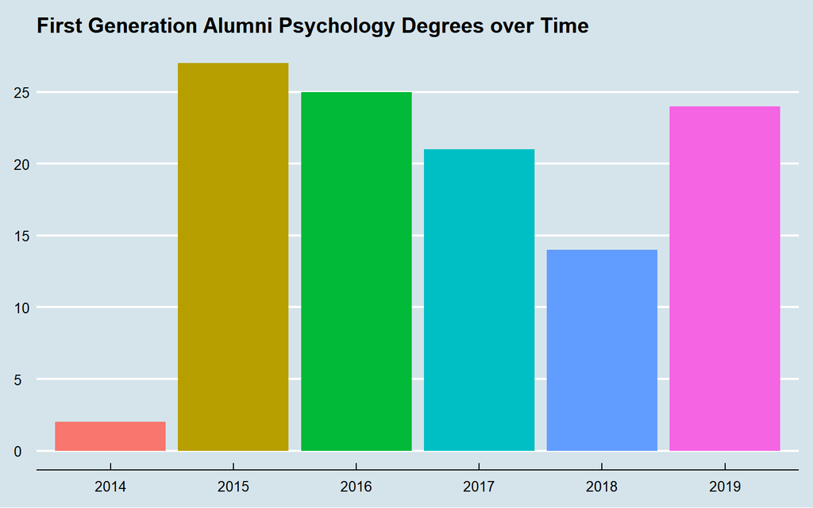

Strategic and Corporate Communication Degrees gained popularity over the last couple of years and has managed to stabilize at a high level of 20 concurrent graduating students for the last two years.

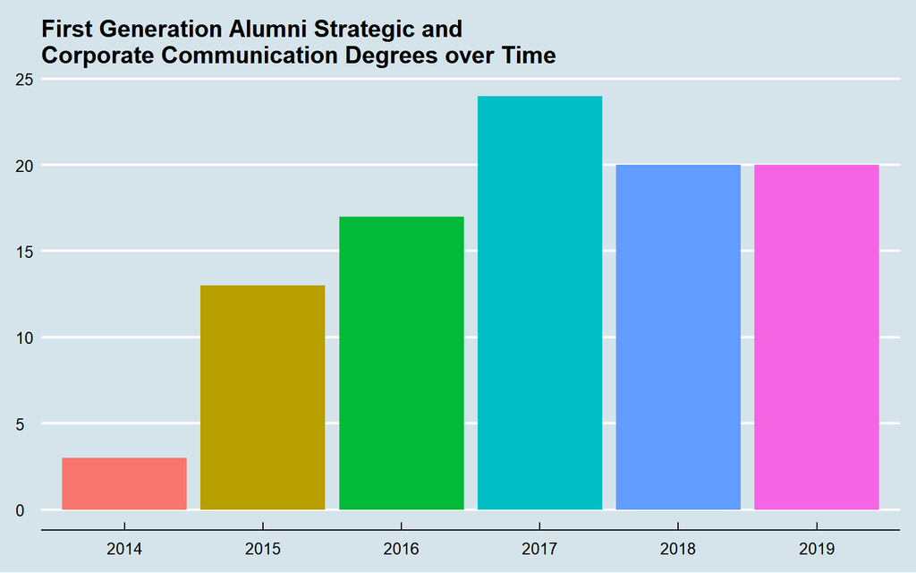

More Popular Degrees for First Generation Alumni are stated in the table below. They fall into the range of greater than 50 graduating individuals and less than 99.

[output not shown]

Biological Science Degrees have been decreasing over time, with a slight uptick in 2019.

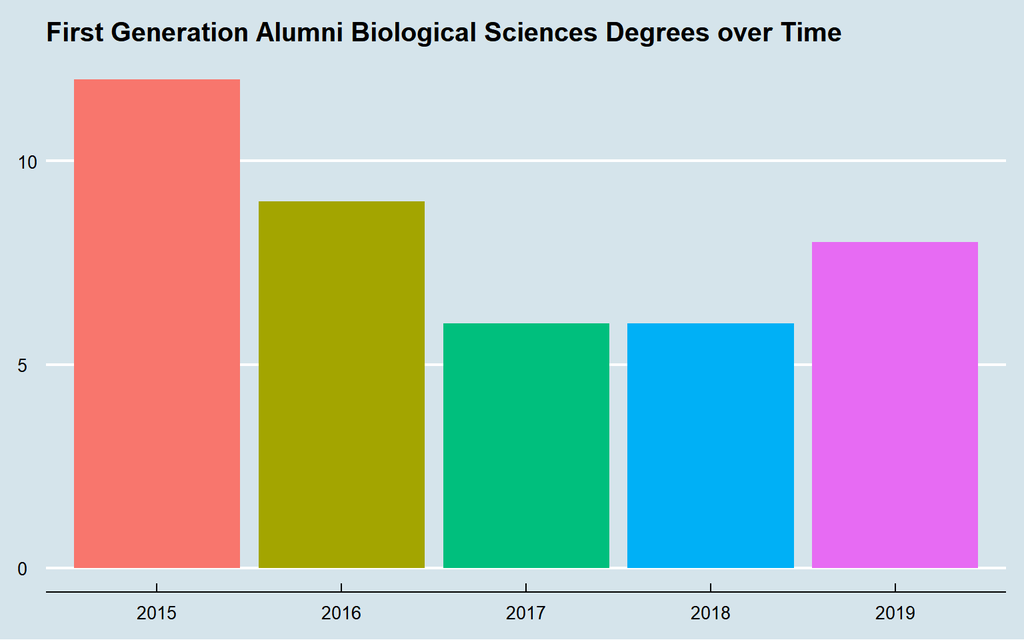

Creative Producing degrees have been fluctuating greatly since we had our first alumni graduate with it in 2014.

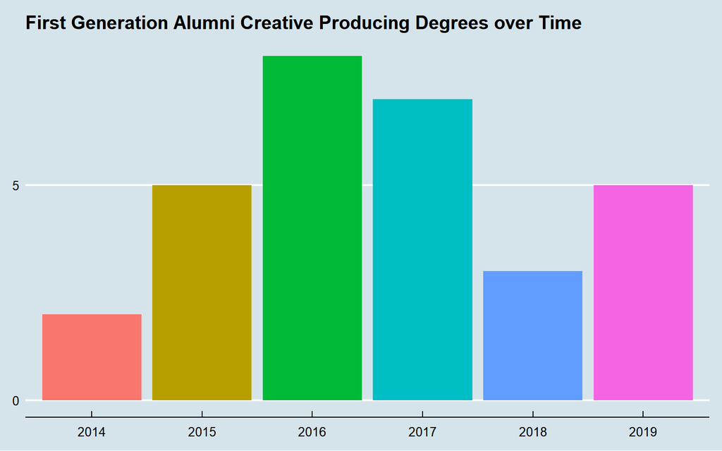

Kinesiology Degrees peaked in 2017 and have since decreased almost to the lowest valley of 2015.

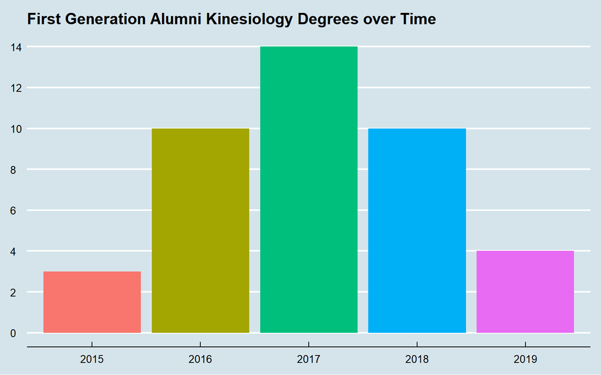

Public relations and advertising degrees spiked in 2015, but have since then been slowly climbing back towards the peak.

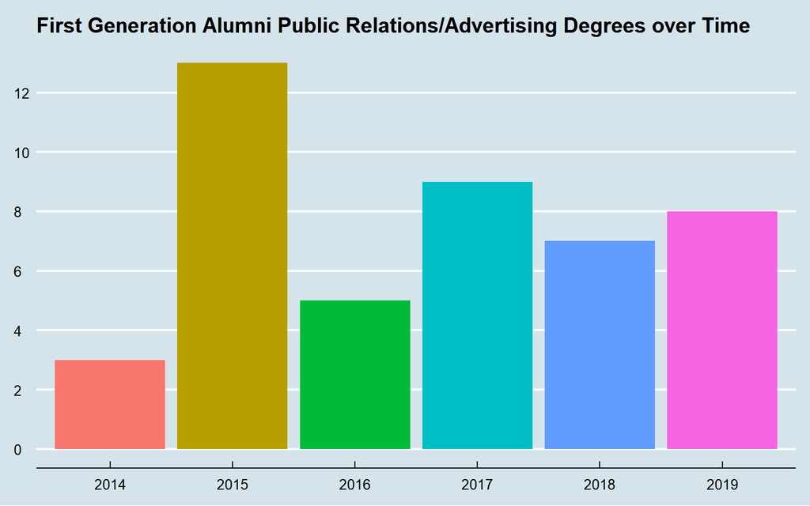

Sociology degrees have maintained a certain level of stability since their spike in popularity in 2015.

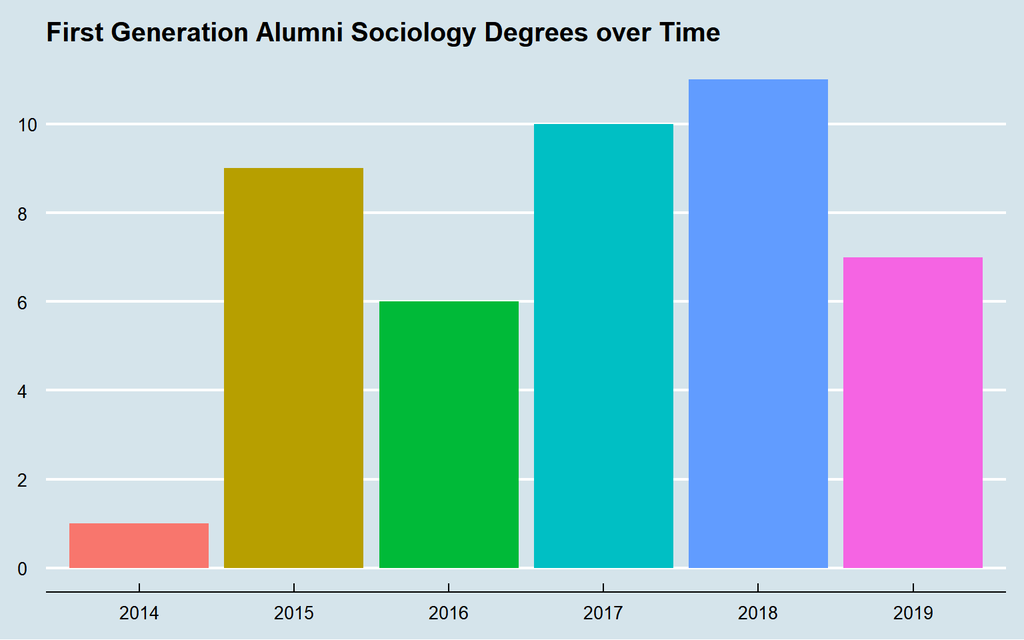

The less Popular Degrees for First Generation Alumni are stated in the table below. They fall into the range of greater than 10 graduating individuals and less than 49. There were no notable trends in these degrees below, so there are no necessary graphs.

| Less Popular Degrees | Count |
| --- | --- |
| Dance Performance | 42 |
| Computer Science | 40 |
| Performance | 40 |
| Film Studies | 34 |
| Peace Studies | 34 |
| Television and Broadcast Journalism | 34 |
| Graphic Design | 32 |
| Biochemistry and Molecular Biology | 30 |
| History | 30 |
| Screenwriting | 30 |
| Philosophy | 26 |
| Athletic Training | 22 |
| Environmental Science & Policy | 22 |
| Television Writing and Production | 22 |
| Curriculum and Instruction | 18 |
| Law | 18 |
| News and Documentary | 18 |
| Theatre Performance | 18 |
| Art History | 16 |
| Leadership Development | 16 |
| Teaching | 16 |
| Theatre | 16 |
| Digital Arts | 14 |
| Art | 12 |
| Dance | 12 |
| Screen Acting | 12 |
| Chemistry | 10 |
| Computational and Data Sciences | 10 |
| Health and Strategic Communication | 10 |
| Music Education | 10 |
| Software Engineering | 10 |

The least Popular Degrees for First Generation Alumni are stated in the table below. They fall into the range of less than 9 graduating individuals. This is a small group of degrees that have the lowest levels of popularity.

| Least Popular Degrees | Count |
| --- | --- |
| Computer Information Systems | 8 |
| Music | 8 |
| French | 6 |
| Health & Strategic Communication | 6 |
| Special Education | 6 |
| Doctor of Pharmacy | 4 |
| Marriage and Family Therapy | 4 |
| Production Design | 4 |
| Religious Studies | 4 |
| Spanish | 4 |
| Anthropology of Culture | 2 |
| Communication Sciences and Disorders | 2 |
| Composition | 2 |
| Economic Systems Design | 2 |
| Educational Psychology | 2 |
| Food Science | 2 |
| International Studies | 2 |
| Medical Anthropology | 2 |
| Physical Therapy | 2 |
| Physics | 2 |
| Public Health | 2 |
| War and Society | 2 |

## 2013 Visualizations - 5 Individuals

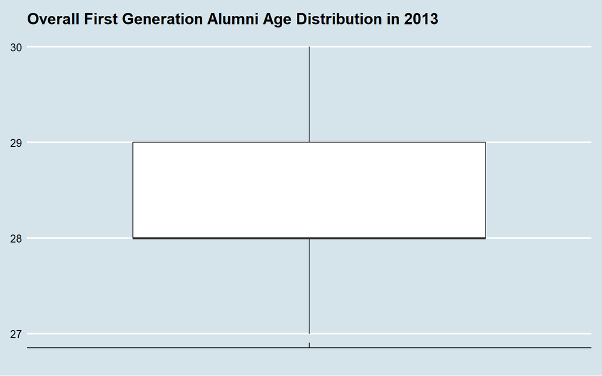

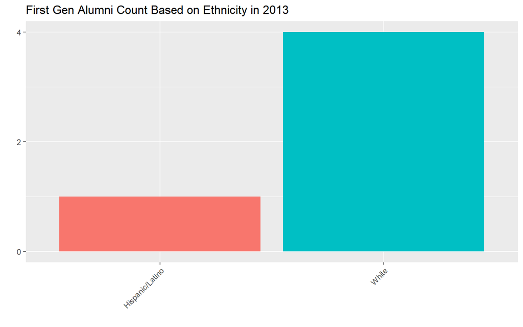

## 2014 Visualizations - 55 Individuals

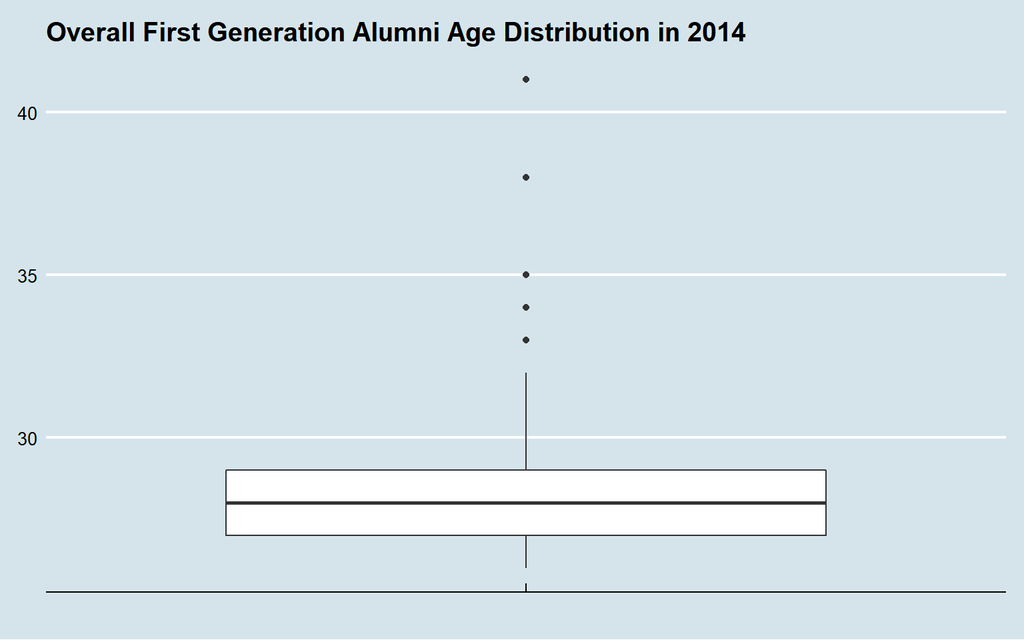

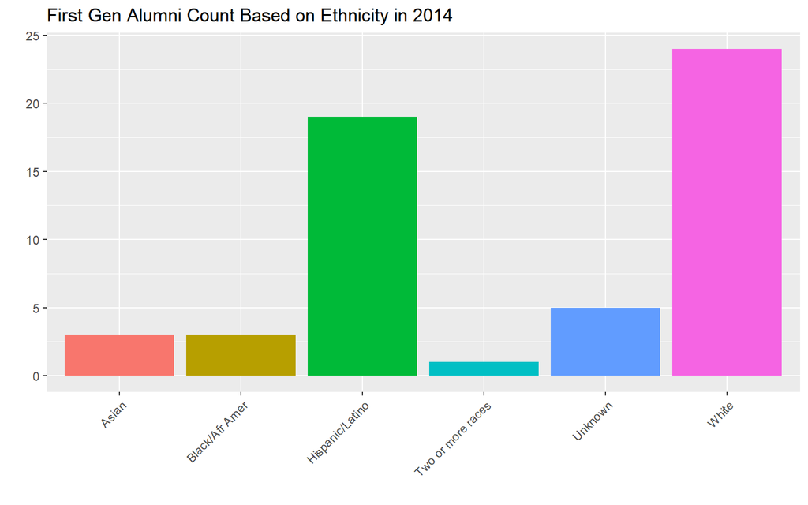

## 2015 Visualizations - 300 Individuals

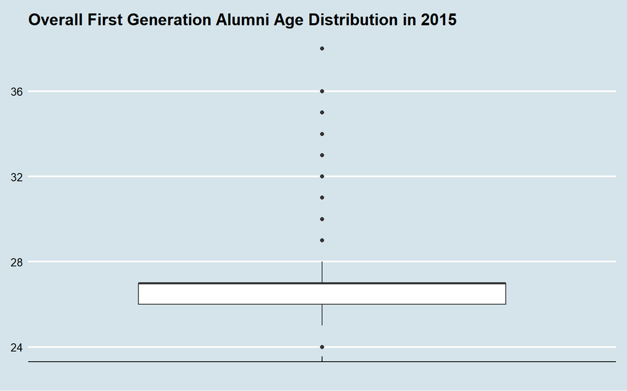

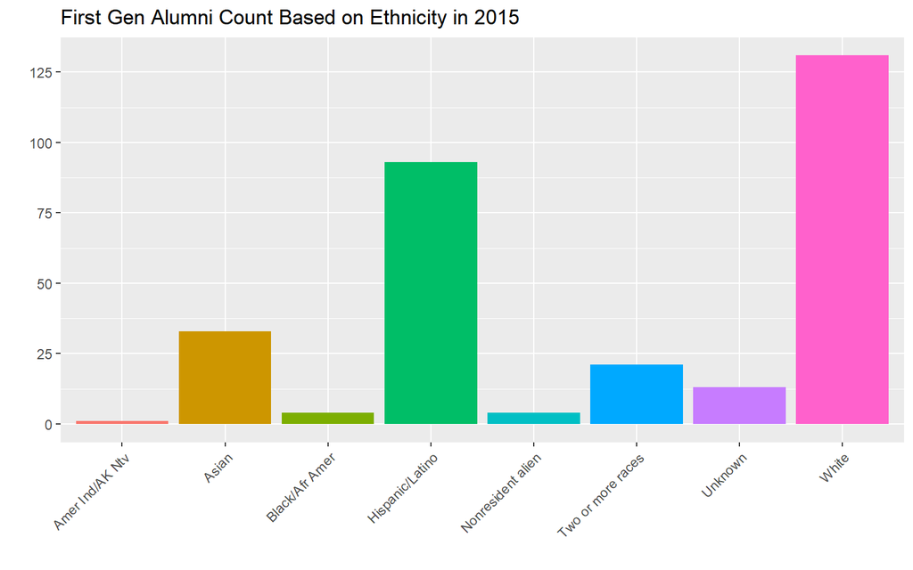

## 2016 Visualizations - 304 Individuals

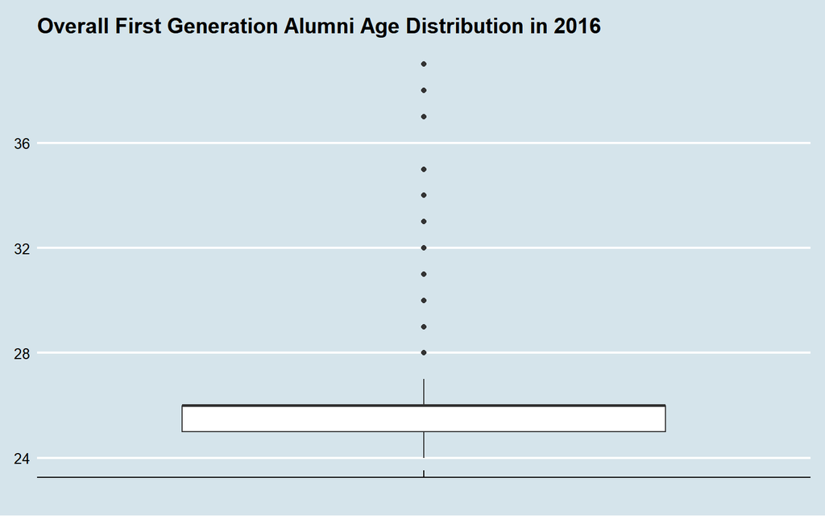

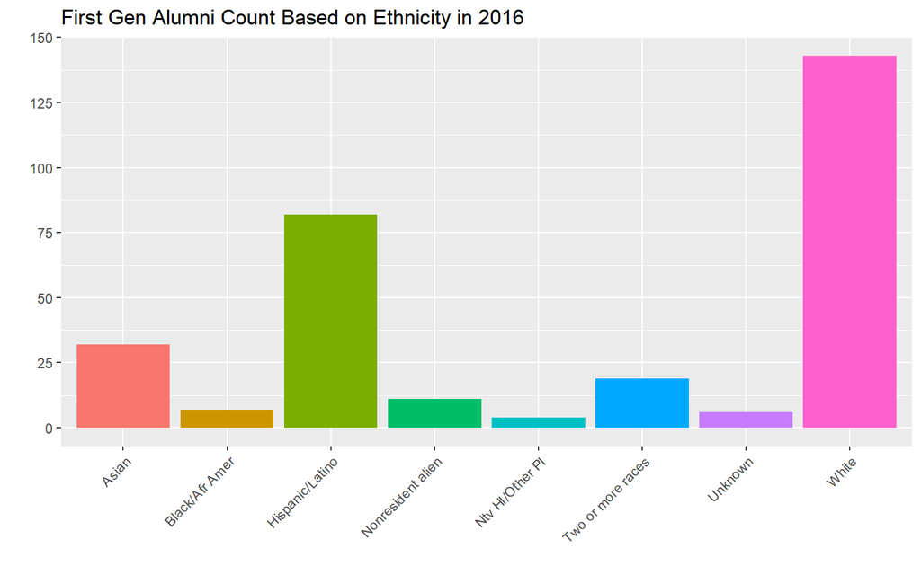

## 2017 Visualizations - 336 Individuals

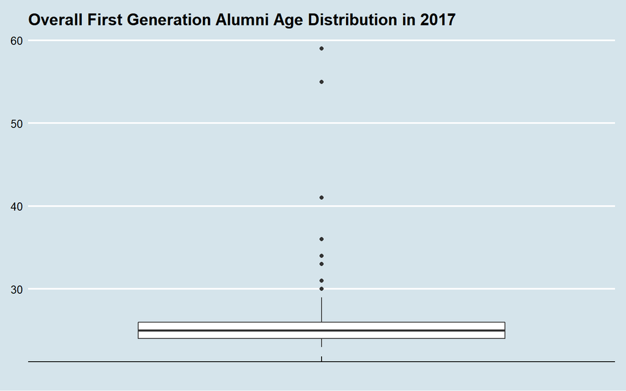

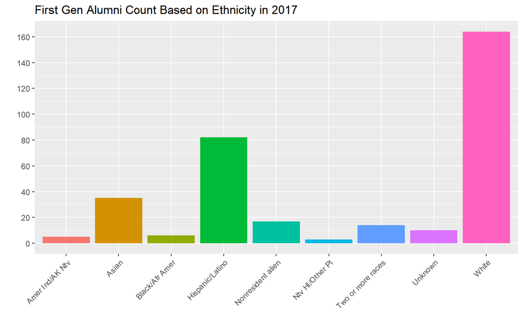

## 2018 Visualizations - 324 Individuals

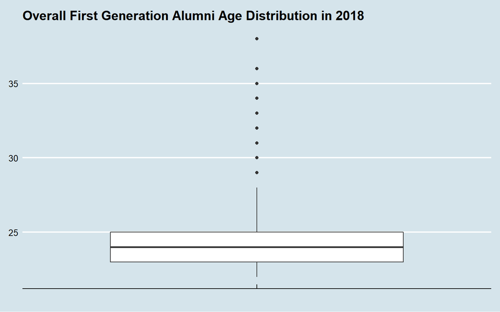

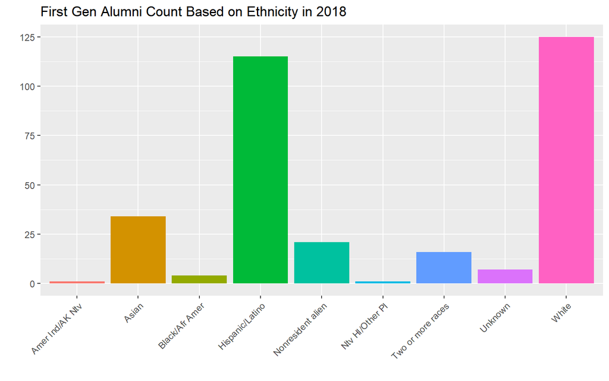